# Estatistica Aplicada

Projecto intercalar

Pedro Magalhães (200202298)

2022-01-03

> Declaro que o presente relatório é de minha autoria e não foi utilizado previamente noutro curso ou unidade curricular, desta ou de outra instituição. As referências a outros autores (afirmações,ideias, pensamentos) respeitam escrupulosamente as regras da atribuição, e encontram-se devidamente indicadasno texto e nas referências bibliográficas, de acordo com as normas de referenciação. Tenho consciência de que a prática de plágio e auto-plágio constitui um ilícito académico.

# Introdução

## Definição da questão

Investir no mercado de capitais implica tomar de decisões de compra de ativos financeiros num contexto de incerteza. De forma a tomarem decisões de investimento em linha com o seu perfil de risco e estratégias diferentes investidores recorrem a diferentes técnicas para entender e prever a evolução do preço do ativo transacionado e identificar oportunidades de entrada (compra) e saída (venda).

No caso de ações cotadas, e comum a utilização da análise técnica que consiste em modelar da evolução temporal do preço de uma ação em face da evolução de determinados indicadores técnicos.

Este projeto estuda a relação linear entre a cotação diária das ações da Microsoft no mercado de valores de Nova York e alguns indicadores técnicos normalmente utilizados neste tipo de análises.

Foram utilizados dados públicos da cotação diária de abertura, de fecho, máxima e mínima entre 01-01-2015 e 31-12-2016 no mercado de Nova York assim como informação das demonstrações financeiras anuais divulgados no site Kaggle.com.

## Critérios de selecção do modelo

O modelo seleccionado é que aquela que apresenta o maior $R^2$ ajustado e menor $AIC$.

## Pressupostos e limitações

Apesar deste projeto estudar a relação linear entre a cotação diária de encerramento e vários indicadores, do ponto de vista da teoria da análise de mercados e da avaliação de carteiras o uso de regressão constitui uma limitação e simplificação. Apesar de válida do ponto de vista académico, na realidade um modelo definido desta forma não permite retirar conclusões adequadas para suportar qualquer conclusão ou decisão.

De entre as limitações e pressupostos assumidos, o mais importante é o pressuposto de **independência entre as observações e consequentemente dos resíduos do modelo**. Dada a natureza dos dados utilizados é de esperar que as observações $y_s$ representando a cotação de fecho do momento S e $y_{s-h}$ representando a observação no momento S-H **não são independentes** estando portante perante uma série temporal.

O estudo dos efeitos autorregressivos contidos na amostra da cotação está fora do âmbito deste projeto pelo que iremos desconsiderar este efeito no modelo e apenas levar em linha de conta sinais externos à série os quais serão dados pelos indicadores técnicos calculados.

# Análise exploratória dos dados

## Descrição da base de dados

```
      date                close            eps           ema_15          ema_30         evwma_30
 Min.   :2015-01-02   Min.   :40.29   Min.   :2.12   Min.   :41.48   Min.   :41.94   Min.   :42.59
 1st Qu.:2015-07-05   1st Qu.:46.23   1st Qu.:2.12   1st Qu.:45.99   1st Qu.:45.76   1st Qu.:45.45
 Median :2016-01-02   Median :51.33   Median :2.12   Median :51.42   Median :51.71   Median :51.46
 Mean   :2016-01-01   Mean   :50.99   Mean   :2.12   Mean   :50.78   Mean   :50.57   Mean   :50.07
 3rd Qu.:2016-07-02   3rd Qu.:55.72   3rd Qu.:2.12   3rd Qu.:54.87   3rd Qu.:54.17   3rd Qu.:53.01
 Max.   :2016-12-30   Max.   :63.62   Max.   :2.12   Max.   :62.65   Max.   :61.82   Max.   :60.35
      rsi             roc                momentum            per_30      per_30_mean
 Min.   :21.82   Min.   :-0.0970986   Min.   :-4.35000   Min.   :19.78   Length:504
 1st Qu.:45.19   1st Qu.:-0.0066319   1st Qu.:-0.34500   1st Qu.:21.58   Class :character
 Median :52.76   Median : 0.0001881   Median : 0.01000   Median :24.39   Mode  :character
 Mean   :53.03   Mean   : 0.0005774   Mean   : 0.03113   Mean   :23.86
 3rd Qu.:61.38   3rd Qu.: 0.0076617   3rd Qu.: 0.36250   3rd Qu.:25.55
 Max.   :84.19   Max.   : 0.0994130   Max.   : 4.84000   Max.   :29.16
 diff_close_open    volatility_cat
 Length:504         Length:504
 Class :character   Class :character
 Mode  :character   Mode  :character
```

A base de dados utilizada contém os seguintes dados:

**date:**

Índice diário entre 2015-01-02 e 2016-12-30

**close:**

Cotação de fecho da sessão diária ajustado por eventuais splits de ações ocorridos durante o ano. (um split de ações significa aumentar o nº de ações em circulação mantendo o mesmo market cap o que gera uma variação abrupta na cotação no momento da realização e no choque de mercado)

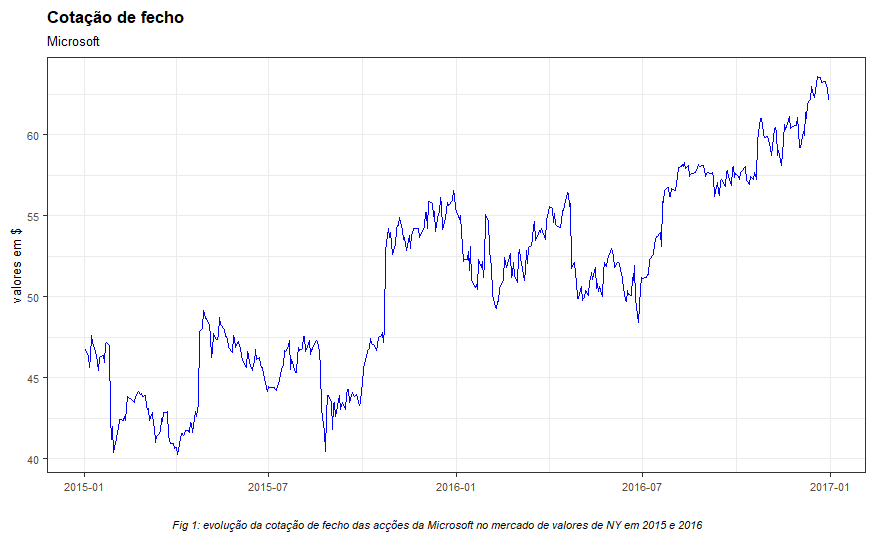

```
<ScaleContinuousDate>
 Range:
 Limits: 1.64e+04 -- 1.72e+04
```

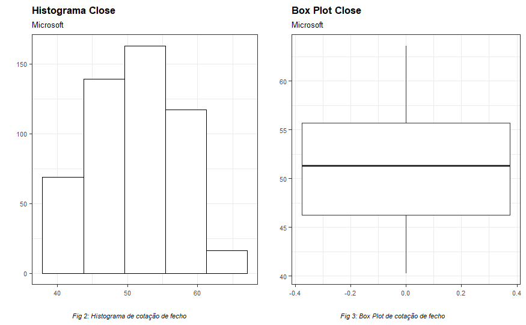

Esta é a Variável dependente que o modelo procura explicar. A figura 2 e 3 descrevem gráficamente a distribuição da amostra. A análise gráfica não parece sugerir que existam outliers.

**low:** mínimo diário a que a acção foi transaccionada

**high:** máximo diário a que a acção foi transaccionada

**volume:** volume de transacções diário

**eps:** Earning per Share anual conforme reportado pelas demonstrações financeiras de final do ano e usando o seguinte rácio

$$EPS = \frac{\text{Net Income}}{\text{Outstanding Shares}}$$

Os dados de low, high, volume e eps foram utilzados para cálculo dos rácio técnicos, mas não serão utilizados para efeito do modelo.

**ema_15 e ema_30**

Exponential Moving Average para a janela de 15 e 30 dias respectivamente.

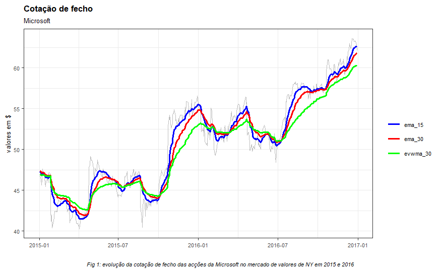

```
<ScaleContinuousDate>
 Range:
 Limits: 1.64e+04 -- 1.72e+04
```

**evwma_30**

Exponential Moving Average Volume Weigthed. Semelhante ao indicador anterior mas corrigido pelo volume de transacção diário

**rsi:**

Relative Strengh Index mensura a força do movimento de subida ou descida em face de um intervalo de evolução. Diferenças entre a evolução deste indicador e a cotação podem indiciar uma inversão da tendência

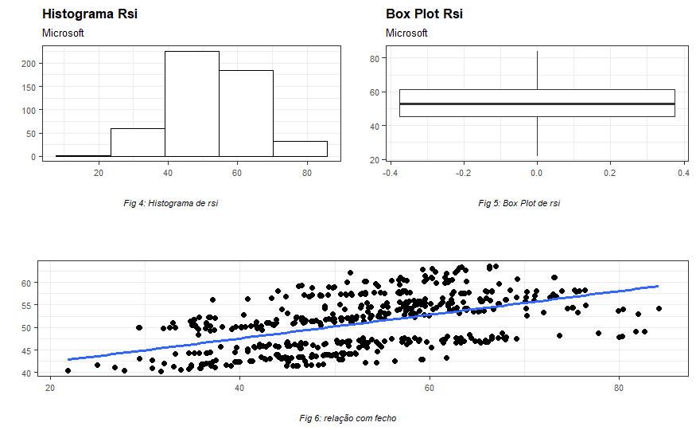

A análise gráfica não indicia a existência de outliers e aparenta existir uma relação linear com a variável dependente.

**roc:**

Percentagem de diferença entre n observações

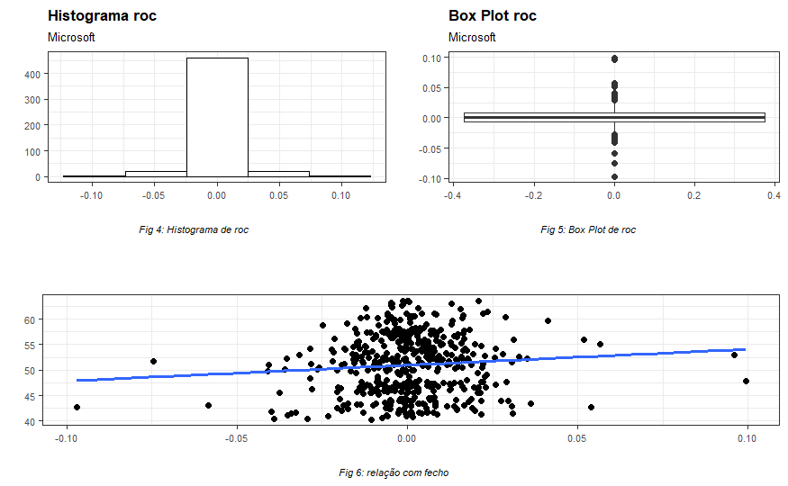

A análise gráfica aponta para a existência de eventuais outliers que necessitariam de ser analisados mais detalhadamente. Comparada com a variável dependente vericamos que existem pontos que indiciam ter um “leverage” elevado.

**momentum:**

Diferença entre n observações (lag)

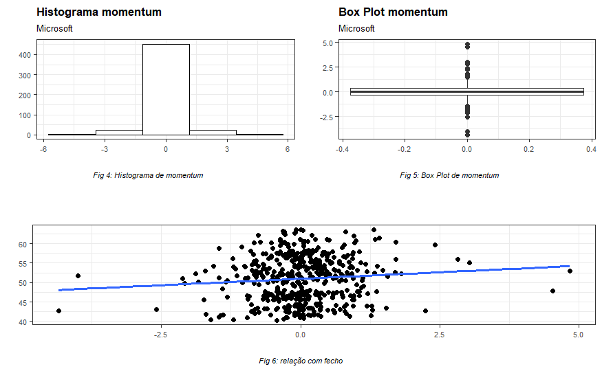

Conclusões idênticas às dp ROC

**per_30:**

Price Earning Ratio 30 days trailing

**per_30_mean:**

Variável categórica que assume valores se per_30 for superior à média dos dois anos então “Higher than average” caso contrário “Lower than average”

**volatility:**

Variância Close-to-Close para uma janela de 15 dias.

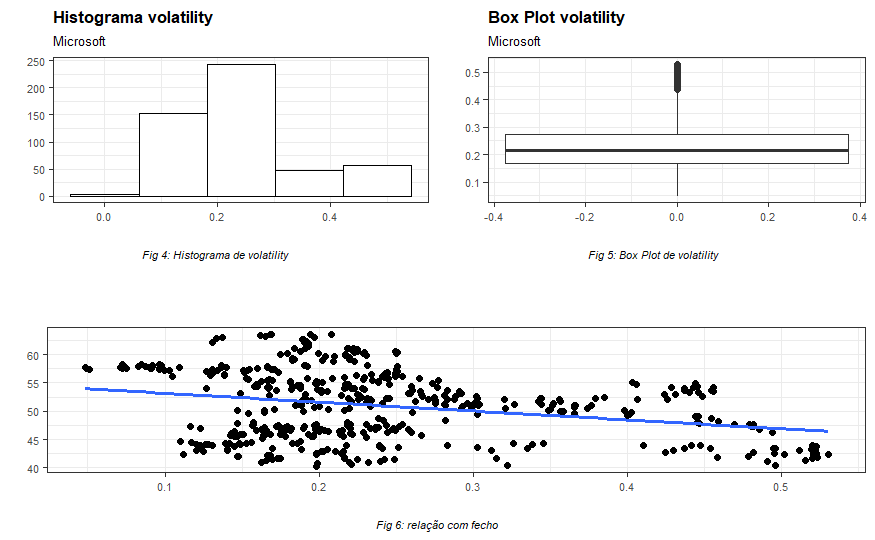

Parece existir uma relação negativa entre as variáveis indiciando quanto maior a volatilidade menor o preço.

**diff_close_open:**

Variável categórica para se ocorreu um ganho intradia (Close > Open) ou uma perda (Close < Open)

## Matriz de correlação

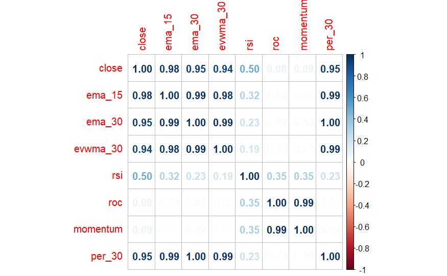

A variável dependente em estudo apresenta uma elevada correlação positiva relativamente à média móvel exponencial a 15, 30 e 30 dias ajustado pelo volume assim como com Price Earning Ratio com 30 dias. Esta conclusão não é surpreendente dado a natureza dos indicadores calculados.

As conclusões da matriz form incorporadas no modelo tendo sido apenas considerado a média movel exponencial ajustada pelo volume por se tratar de um indicador sintetico mais completo.

# Modelos e avaliação

| model | model_name | r2 | aic |
| --- | --- | --- | --- |
| close ~ +evwma_30 * volatility_cat + rsi * volatility_cat + momentum * volatility_cat + per_30 * volatility_cat + per_30_mean + diff_close_open | relation | 0.9982627918 | 63.14073 |
| close ~ ema_15 + ema_30 + evwma_30 + rsi + roc + momentum + per_30 + volatility_cat + per_30_mean + diff_close_open | complete | 0.9967123072 | 364.64571 |
| close ~ +evwma_30 + rsi + momentum + per_30 + volatility_cat + per_30_mean + diff_close_open | adjusted | 0.9947052847 | 600.81338 |
| close ~ ema_15 | ema_15 | 0.9516442157 | 1699.59921 |
| close ~ ema_30 | ema_30 | 0.9082888347 | 2022.18859 |
| close ~ per_30 | per_30 | 0.9082888347 | 2022.18859 |
| close ~ evwma_30 | evwma_30 | 0.8778742520 | 2166.53777 |
| close ~ per_30_mean | per_30_mean | 0.6775435953 | 2655.87979 |
| close ~ rsi | rsi | 0.2522894194 | 3079.76800 |
| close ~ volatility_cat | volatility | 0.0492617061 | 3204.84032 |

[output cut: 3 more lines]

```
Call:
lm(formula = ., data = msft_prices_2015_2016_df)

Residuals:
     Min       1Q   Median       3Q      Max
-0.80955 -0.13018 -0.00987  0.14760  0.96825

Coefficients:
                                               Estimate Std. Error t value Pr(>|t|)
(Intercept)                                   -9.880514   0.532082 -18.570  < 2e-16 ***
evwma_30                                      -0.131555   0.057815  -2.275   0.0233 *
volatility_catLow Volatility                   5.161957   0.511693  10.088  < 2e-16 ***
volatility_catMedium High volatility           3.735717   0.465725   8.021 8.01e-15 ***
volatility_catMedium Low volatility            3.994074   0.484536   8.243 1.60e-15 ***
rsi                                            0.188753   0.001683 112.180  < 2e-16 ***
momentum                                       0.025695   0.022622   1.136   0.2566
per_30                                         2.414443   0.114123  21.156  < 2e-16 ***
per_30_meanLower than average                 -0.105449   0.057056  -1.848   0.0652 .
diff_close_openintraday loss                   0.006103   0.028003   0.218   0.8276
evwma_30:volatility_catLow Volatility          0.058243   0.075785   0.769   0.4426
evwma_30:volatility_catMedium High volatility  0.069441   0.068923   1.008   0.3142
evwma_30:volatility_catMedium Low volatility  -0.085048   0.072918  -1.166   0.2441
volatility_catLow Volatility:rsi              -0.083029   0.003382 -24.547  < 2e-16 ***
volatility_catMedium High volatility:rsi      -0.047919   0.003371 -14.217  < 2e-16 ***
volatility_catMedium Low volatility:rsi       -0.058341   0.003777 -15.445  < 2e-16 ***
volatility_catLow Volatility:momentum         -0.020292   0.064056  -0.317   0.7515
volatility_catMedium High volatility:momentum  0.048687   0.039911   1.220   0.2231
volatility_catMedium Low volatility:momentum  -0.006696   0.045145  -0.148   0.8822
volatility_catLow Volatility:per_30           -0.160945   0.149769  -1.075   0.2831
volatility_catMedium High volatility:per_30   -0.197417   0.138575  -1.425   0.1549
volatility_catMedium Low volatility:per_30     0.139666   0.146414   0.954   0.3406
---
Signif. codes:  0 ‘***’ 0.001 ‘**’ 0.01 ‘*’ 0.05 ‘.’ 0.1 ‘ ’ 1

Residual standard error: 0.2517 on 482 degrees of freedom
Multiple R-squared:  0.9983,    Adjusted R-squared:  0.9982
F-statistic: 1.319e+04 on 21 and 482 DF,  p-value: < 2.2e-16
```

# Estudo dos residuos

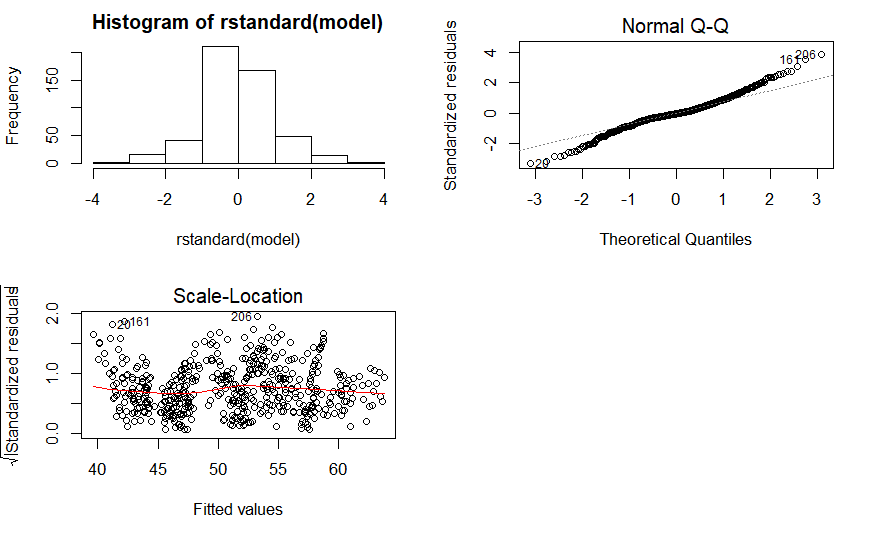

Da análise gráfica não parece existir indicidos de heterostacidade nos resíduos, mas o gráfico de Normal Q-Q apresenta algum desvio que pode impactar o resultado de testes estatísticos.

# Questões sobre Regressão Linear

e.2.)

```
Call:
lm(formula = close ~ evwma_30 * volatility_cat + rsi * volatility_cat +
    per_30, data = msft_prices_2015_2016_df)

Residuals:
     Min       1Q   Median       3Q      Max
-0.82584 -0.12072 -0.01055  0.12677  0.95040

Coefficients:
                                                Estimate Std. Error t value Pr(>|t|)
(Intercept)                                   -10.680199   0.343397 -31.102  < 2e-16 ***
evwma_30                                       -0.078522   0.022956  -3.421 0.000677 ***
volatility_catLow Volatility                    5.650334   0.422973  13.359  < 2e-16 ***
volatility_catMedium High volatility            4.176813   0.425397   9.819  < 2e-16 ***
volatility_catMedium Low volatility             3.896212   0.412710   9.441  < 2e-16 ***
rsi                                             0.189357   0.001559 121.495  < 2e-16 ***
per_30                                          2.333691   0.045124  51.718  < 2e-16 ***
evwma_30:volatility_catLow Volatility          -0.027200   0.008178  -3.326 0.000947 ***
evwma_30:volatility_catMedium High volatility  -0.034028   0.008404  -4.049 5.98e-05 ***
evwma_30:volatility_catMedium Low volatility   -0.020394   0.007686  -2.653 0.008230 **
volatility_catLow Volatility:rsi               -0.084295   0.002848 -29.600  < 2e-16 ***
volatility_catMedium High volatility:rsi       -0.047240   0.003006 -15.716  < 2e-16 ***
volatility_catMedium Low volatility:rsi        -0.054953   0.003253 -16.892  < 2e-16 ***
---
Signif. codes:  0 ‘***’ 0.001 ‘**’ 0.01 ‘*’ 0.05 ‘.’ 0.1 ‘ ’ 1

Residual standard error: 0.2544 on 491 degrees of freedom
Multiple R-squared:  0.9982,    Adjusted R-squared:  0.9981
F-statistic: 2.259e+04 on 12 and 491 DF,  p-value: < 2.2e-16
```

e4)

```
Start:  AIC=-1367.01
close ~ evwma_30 * volatility_cat + rsi * volatility_cat + per_30

                          Df Sum of Sq     RSS      AIC
<none>                                  31.775 -1367.01
- evwma_30:volatility_cat  3     1.149  32.924 -1355.11
- volatility_cat:rsi       3    63.000  94.775  -822.22
- per_30                   1   173.092 204.866  -429.71

Call:
lm(formula = close ~ evwma_30 * volatility_cat + rsi * volatility_cat +
    per_30, data = msft_prices_2015_2016_df)

Coefficients:
                                  (Intercept)                                       evwma_30
                                    -10.68020                                       -0.07852
                 volatility_catLow Volatility           volatility_catMedium High volatility
                                      5.65033                                        4.17681
          volatility_catMedium Low volatility                                            rsi
                                      3.89621                                        0.18936
                                       per_30          evwma_30:volatility_catLow Volatility
                                      2.33369                                       -0.02720
evwma_30:volatility_catMedium High volatility   evwma_30:volatility_catMedium Low volatility
                                     -0.03403                                       -0.02039
             volatility_catLow Volatility:rsi       volatility_catMedium High volatility:rsi
                                     -0.08429                                       -0.04724
      volatility_catMedium Low volatility:rsi
                                     -0.05495
```

Sem impacto significativo no modelo e nos coefecientes estimados.

e5) Efeito já incluido no modelo estudado